# DynamitePackage

Tanya Toluay

2025-02-05

## Data Simulation

We simulate data for 100 individuals across 10 time points.

For each individual, we have two time series: one for alcohol scores and one for depression scores. These scores are created using a random walk, where each score is the cumulative sum of random values drawn from a normal distribution.

A random walk can increase, decrease, or remain relatively stable, depending on the sequence of random values. It’s just that each new value is influenced by the sum of all the previous random changes.

```r
set.seed(1)

# Simulate data for 100 individuals across 10 time points
n_id <- 100
n_time <- 10
sim_data <- expand.grid(id = 1:n_id, time = 1:n_time)

# Generate alcohol and depression scores with some autocorrelation
sim_data <- sim_data %>%
  group_by(id) %>%
  mutate(
    alcohol = cumsum(rnorm(n_time, mean = 0, sd = 1)),  # Random walk
    depression = cumsum(rnorm(n_time, mean = 0, sd = 1)) # Random walk
  ) %>%
  ungroup()
```

### Overall Trend Across 100 Individuals

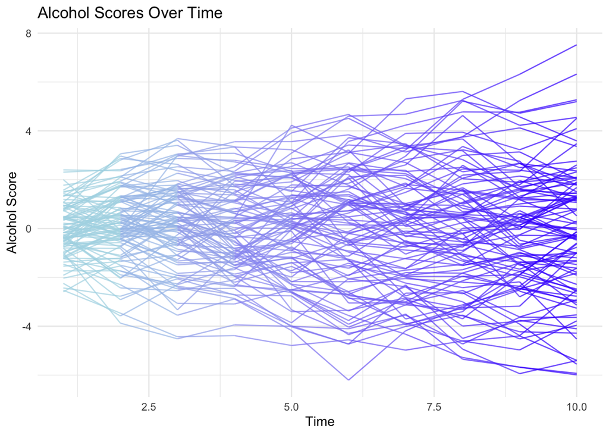

```r
ggplot(sim_data, aes(x = time, y = alcohol, group = id, color = time)) +
  geom_line(alpha = 0.7) +
  scale_color_gradient(low = "lightblue", high = "blue") +
  theme_minimal() +
  labs(title = "Alcohol Scores Over Time", x = "Time", y = "Alcohol Score") +
  theme(legend.position = "none")
```

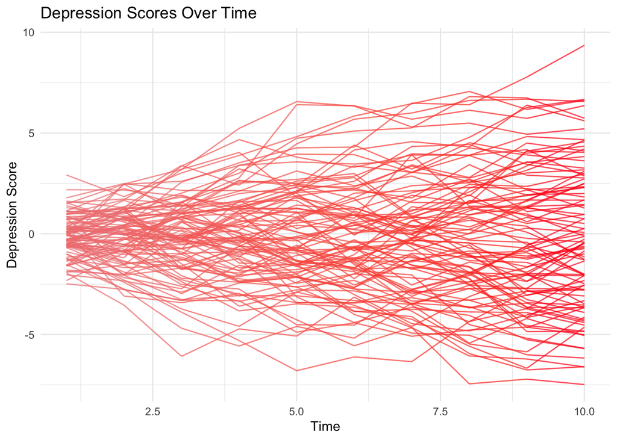

```r
ggplot(sim_data, aes(x = time, y = depression, group = id, color = time)) +
  geom_line(alpha = 0.7) +
  scale_color_gradient(low = "lightcoral", high = "red") +
  theme_minimal() +
  labs(title = "Depression Scores Over Time", x = "Time", y = "Depression Score") +
  theme(legend.position = "none")
```